# Lecture 5: Correlation, Linear Regression and Prediction

## MLB Batting Statistics

Let’s first load the `Lahman` library used in Lecture 4.

```r
library(Lahman)
batting <- as_tibble(Batting)
```

In the code below, we’ll create a dataset containing player batting averages from the 2017 and 2018 seasons. We keep players with at least 300 at-bats in both seasons and reshape the data so that each player has one row and each season has its own column.

```r
batting_2017_2018 <- batting %>%
  filter(yearID %in% c(2017, 2018)) %>%
  group_by(playerID, yearID) %>%
  reframe(H = sum(H), AB = sum(AB)) %>%
  filter(AB >= 300) %>%
  mutate(BA = H / AB) %>%
  ungroup() %>%
  group_by(playerID) %>%
  filter(n() == 2) %>%
  ungroup() %>%
  select(playerID, yearID, BA) %>%
  pivot_wider(
    names_from = yearID,
    values_from = BA,
    names_prefix = "BA_"
  ) %>%
  arrange(playerID)

batting_2017_2018
```

```
## # A tibble: 196 × 3
##    playerID  BA_2017 BA_2018
##    <chr>       <dbl>   <dbl>
##  1 abreujo02   0.304   0.265
##  2 adamsma01   0.274   0.239
##  3 alonsyo01   0.266   0.25
##  4 altuvjo01   0.346   0.316
##  5 anderti01   0.257   0.240
##  6 andruel01   0.297   0.256
##  7 arciaor01   0.277   0.236
##  8 arenano01   0.309   0.297
##  9 baezja01    0.273   0.290
## 10 barnhtu01   0.270   0.248
## # ℹ 186 more rows
```

## Predicting Batting Averages

We start by plotting each player’s 2017 batting average against their 2018 batting average.

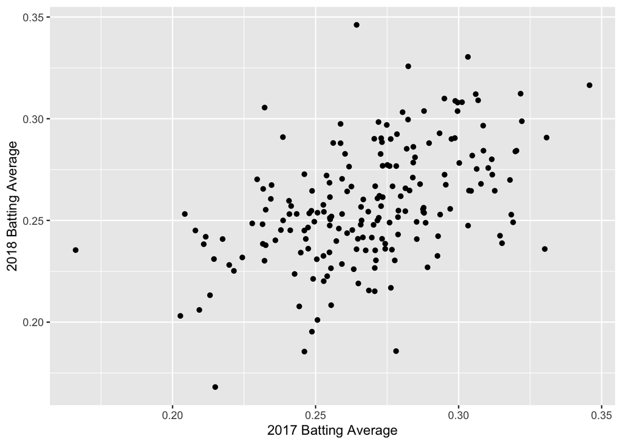

```r
ba_plot <- batting_2017_2018 %>%
  ggplot(aes(x = BA_2017, y = BA_2018)) +
  geom_point() +
  labs(x = "2017 Batting Average", y = "2018 Batting Average")

ba_plot
```

### Correlation

The **correlation coefficient**, $r$, summarizes the linear relationship between two variables. It ranges from -1 to 1: values near 1 indicate a strong positive linear relationship, values near -1 indicate a strong negative linear relationship, and values near 0 indicate a weak linear relationship.

We can calculate the correlation between the 2017 and 2018 batting averages with `cor()`:

```r
cor(batting_2017_2018$BA_2017, batting_2017_2018$BA_2018)
```

```
## [1] 0.4795003
```

The two seasons have a moderate positive correlation, but there is still a lot of variation from player to player. Remember that correlation measures only a *linear* relationship; variables can be related in other ways even when their correlation is close to zero.

### Fitting a Linear Model

We can describe the linear relationship and use it for prediction by fitting a linear model with `lm()`:

```r
fit <- lm(BA_2018 ~ BA_2017, data = batting_2017_2018)
```

The first argument is a formula in the form `response ~ predictor`. Here, `BA_2018` is the response we want to predict and `BA_2017` is the predictor. The `data` argument tells R where to find those variables.

The fitted model contains the intercept and slope of the regression line:

```r
fit$coefficients
```

```
## (Intercept)     BA_2017
##   0.1305237   0.4735976
```

We can use those coefficients to add the fitted line to our scatterplot.

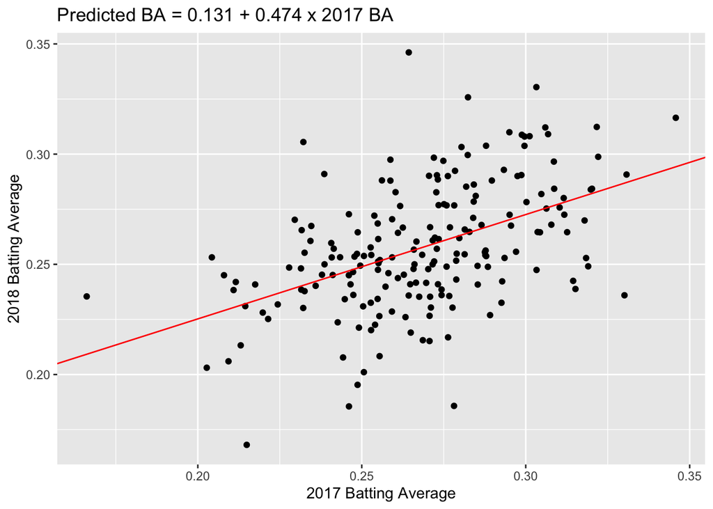

```r
intercept <- fit$coefficients[[1]]
slope <- fit$coefficients[[2]]

ba_plot <- ba_plot +
  geom_abline(intercept = intercept, slope = slope, color = "red") +
  labs(
    title = paste0(
      "Predicted BA = ", round(intercept, 3),
      " + ", round(slope, 3), " x 2017 BA"
    )
  )

ba_plot
```

**Question:** How would you interpret the slope? What does the model predict will happen to 2018 batting average when 2017 batting average increases by 0.010?

### Predictions and Residuals

The function `predict()` uses the fitted model to calculate a predicted 2018 batting average for every player in the data. A **residual** is the difference between a player’s actual and predicted batting average.

```r
batting_2017_2018 <- batting_2017_2018 %>%
  mutate(
    pred = predict(fit),
    resid = BA_2018 - pred
  )

batting_2017_2018
```

```
## # A tibble: 196 × 5
##    playerID  BA_2017 BA_2018  pred    resid
##    <chr>       <dbl>   <dbl> <dbl>    <dbl>
##  1 abreujo02   0.304   0.265 0.275 -0.0101
##  2 adamsma01   0.274   0.239 0.260 -0.0219
##  3 alonsyo01   0.266   0.25  0.257 -0.00654
##  4 altuvjo01   0.346   0.316 0.294  0.0222
##  5 anderti01   0.257   0.240 0.252 -0.0125
##  6 andruel01   0.297   0.256 0.271 -0.0155
##  7 arciaor01   0.277   0.236 0.262 -0.0259
##  8 arenano01   0.309   0.297 0.277  0.0199
##  9 baezja01    0.273   0.290 0.260  0.0307
## 10 barnhtu01   0.270   0.248 0.259 -0.0107
## # ℹ 186 more rows
```

We can draw each residual as the vertical distance between an observed value and the fitted line.

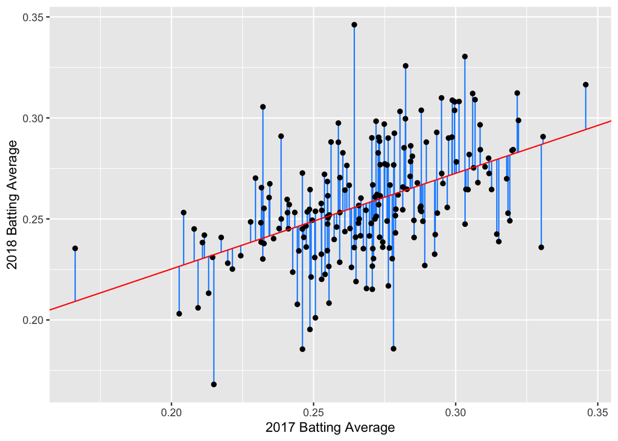

```r
ggplot(batting_2017_2018) +
  geom_segment(
    aes(x = BA_2017, xend = BA_2017, y = BA_2018, yend = pred),
    color = "dodgerblue"
  ) +
  geom_point(aes(x = BA_2017, y = BA_2018)) +
  geom_abline(intercept = intercept, slope = slope, color = "red") +
  labs(x = "2017 Batting Average", y = "2018 Batting Average")
```

Another way to summarize the fit is $R^2$, the proportion of variation in the response explained by the model. We can obtain it from the model summary:

```r
summary(fit)$r.squared
```

```
## [1] 0.2299205
```

### Predicting New Observations

So far, we have predicted values for the same players used to fit the model. Suppose we know three other players’ 2017 batting averages but not their 2018 batting averages. We can pass a new tibble to the `newdata` argument of `predict()`.

```r
new_data <- tibble(BA_2017 = c(0.241, 0.310, 0.265))

new_data <- new_data %>%
  mutate(pred = predict(fit, newdata = new_data))

new_data
```

```
## # A tibble: 3 × 2
##   BA_2017  pred
##     <dbl> <dbl>
## 1   0.241 0.245
## 2   0.31  0.277
## 3   0.265 0.256
```

Finally, we add the new predictions to the original plot.

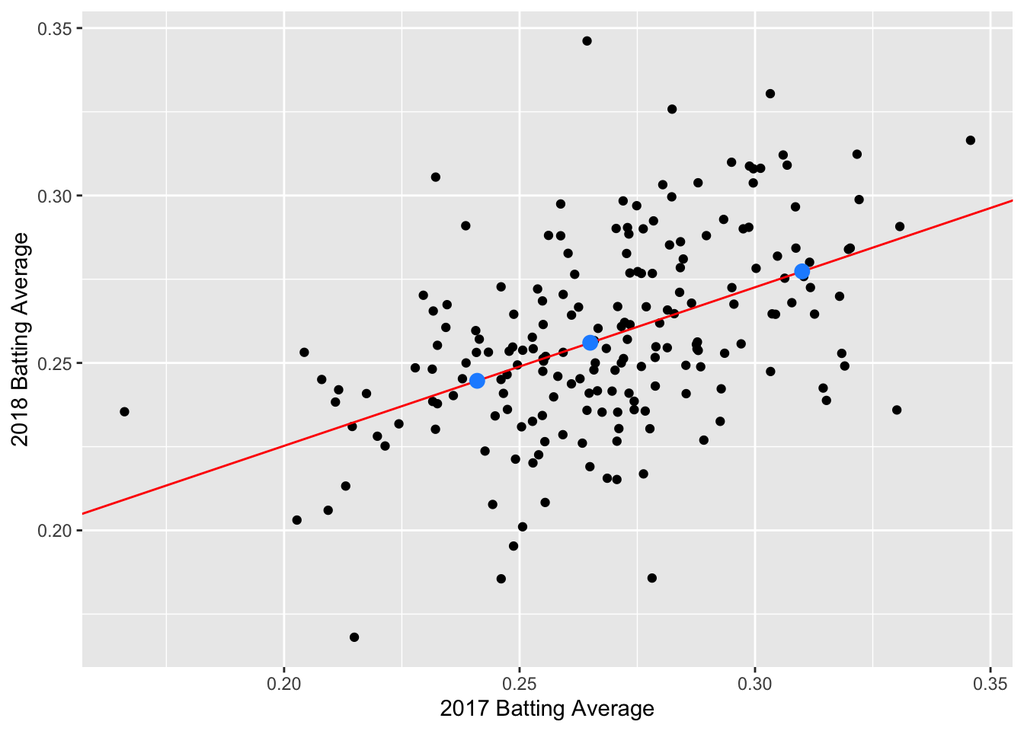

```r
ggplot(batting_2017_2018, aes(x = BA_2017, y = BA_2018)) +
  geom_point() +
  geom_abline(intercept = intercept, slope = slope, color = "red") +
  geom_point(
    data = new_data,
    aes(x = BA_2017, y = pred),
    color = "dodgerblue",
    size = 3
  ) +
  labs(x = "2017 Batting Average", y = "2018 Batting Average")
```